# Estat de l’art sobre la validació clínica de solucions digitals en l’ambit de la salut

Informe estadístic

Jordi Real. Impuls digital

24 octubre, 2023

DRAFT

# Objectivos

## Objetivo principal

L’objectiu d’aquest manuscrit és revisar l’estat de l’art de la validació clínica de solucions digitals en el camp de la salut. S’exploraran els diferents mètodes utilitzats per avaluar l’eficàcia i seguretat clínica d’aquestes solucions, així com els desafiaments comuns que es troben en aquest procés. A més, s’identificaran les millors pràctiques en la validació clínica i es discutiran les perspectives futures per a un enfocament més eficaç en aquest àmbit en constant evolució.

# Estatus

### Fet

- Definició d’estrategia de cerca
- Cerca bibliografica
- Descarrega de papers resum
- Captura de dissenys del Abstract
- tipus de Journal
- Descriptiva general
- Proposta d’anàlisi bibliomètric

### Pendent

- Definir estrategia d’anàlisi principal

# Mètode

((((“salut digital”[Tèrm de relació]) O (“Salut digital”[Títol/Resum]) O (eSalut[Tèrm de relació]) O (mSalut[Tèrm de relació]) O (Telemedicina[Tema principal de MeSH])) I ((“Validació clínica”[Tèrm de relació]) O “validació clínica” O “qualitat clínica” O “Qualitat de l’aplicació” O “acreditació” O (“Validació”[Títol/Resum]) ))

Es va realitzar un anàlisi bibliomètric descriptiu de la cerca realitzada. Les variables es van generar mitjançant cerques de paraules clau en el títol i el resum, tals com: tipus de disseny, retrospectiu/prospectiu, estudi d’usabilitat i qüestionari de validació. A més a més es va capturar l’àmbit d’aplicació i el quartil de la revista.

Es va realitzar un analisi descriptiva de freqüències de les variables relatives, anàlisi gràfic, núvol de paraules trobades en el resum i un mapa gràfic segons la regió del país del primer autor de l’article.”

```
##
## --------Summary descriptives table ---------
##
## _______________________________________________
##                                  [ALL]      N
##                                  N=1801
## ¯¯¯¯¯¯¯¯¯¯¯¯¯¯¯¯¯¯¯¯¯¯¯¯¯¯¯¯¯¯¯¯¯¯¯¯¯¯¯¯¯¯¯¯¯¯¯
## Study.Status:                              1801
##     ACTIVE_NOT_RECRUITING     107 (5.94%)
##     COMPLETED                 839 (46.6%)
##     ENROLLING_BY_INVITATION    31 (1.72%)
##     NOT_YET_RECRUITING        177 (9.83%)
##     RECRUITING                412 (22.9%)
##     SUSPENDED                  4 (0.22%)
##     TERMINATED                 30 (1.67%)
##     UNKNOWN                   157 (8.72%)
##     WITHDRAWN                  44 (2.44%)
## Sex:                                       1801
##     ALL                       1526 (84.7%)
##     FEMALE                    211 (11.7%)
##     MALE                       64 (3.55%)
## Age:                                       1801
##     ADULT                     198 (11.0%)
##     ADULT, OLDER_ADULT        1141 (63.4%)
##     CHILD                     118 (6.55%)
##     CHILD, ADULT              168 (9.33%)
##     CHILD, ADULT, OLDER_ADULT 147 (8.16%)
##     OLDER_ADULT                29 (1.61%)
## Phases:                                    230
##                               153 (66.5%)
##     EARLY_PHASE1               14 (6.09%)
##     PHASE1                     15 (6.52%)
##     PHASE1|PHASE2              5 (2.17%)
##     PHASE2                     16 (6.96%)
##     PHASE2|PHASE3              5 (2.17%)
##     PHASE3                     12 (5.22%)
##     PHASE4                     10 (4.35%)
## Enrollment                    2226 (48863) 1801
## Funder.Type:                               1801
##     FED                        22 (1.22%)
##     INDUSTRY                  103 (5.72%)
##     NETWORK                    4 (0.22%)
##     NIH                        3 (0.17%)
##     OTHER                     1643 (91.2%)
##     OTHER_GOV                  26 (1.44%)
## Study.Type:                                1801
##     INTERVENTIONAL            1648 (91.5%)
##     OBSERVATIONAL             153 (8.50%)
## ¯¯¯¯¯¯¯¯¯¯¯¯¯¯¯¯¯¯¯¯¯¯¯¯¯¯¯¯¯¯¯¯¯¯¯¯¯¯¯¯¯¯¯¯¯¯¯
```

```
##
## --------Summary descriptives table ---------
##
## ___________________________________________
##                                [ALL]     N
##                                N=326
## ¯¯¯¯¯¯¯¯¯¯¯¯¯¯¯¯¯¯¯¯¯¯¯¯¯¯¯¯¯¯¯¯¯¯¯¯¯¯¯¯¯¯¯
## Rank                        164 (94.3)  326
## Status:                                 326
##     Active, not recruiting  20 (6.13%)
##     Completed               125 (38.3%)
##     Enrolling by invitation  9 (2.76%)
##     Not yet recruiting      32 (9.82%)
##     Recruiting              94 (28.8%)
##     Suspended                2 (0.61%)
##     Terminated               4 (1.23%)
##     Unknown status          34 (10.4%)
##     Withdrawn                6 (1.84%)
## Study.Results:                          326
##     Has Results             18 (5.52%)
##     No Results Available    308 (94.5%)
## Gender:                                 326
##     All                     298 (91.4%)
##     Female                  26 (7.98%)
##     Male                     2 (0.61%)
## Phases:                                 326
##                             67 (20.6%)
##     Early Phase 1            2 (0.61%)
##     Not Applicable          241 (73.9%)
##     Phase 1                  2 (0.61%)
##     Phase 2                  9 (2.76%)
##     Phase 3                  3 (0.92%)
##     Phase 4                  2 (0.61%)
## Enrollment                  396 (1445)  326
## Study.Type:                             326
##     Interventional          259 (79.4%)
##     Observational           67 (20.6%)
## ¯¯¯¯¯¯¯¯¯¯¯¯¯¯¯¯¯¯¯¯¯¯¯¯¯¯¯¯¯¯¯¯¯¯¯¯¯¯¯¯¯¯¯
```

# Resultats

## Wordcloud Keywords

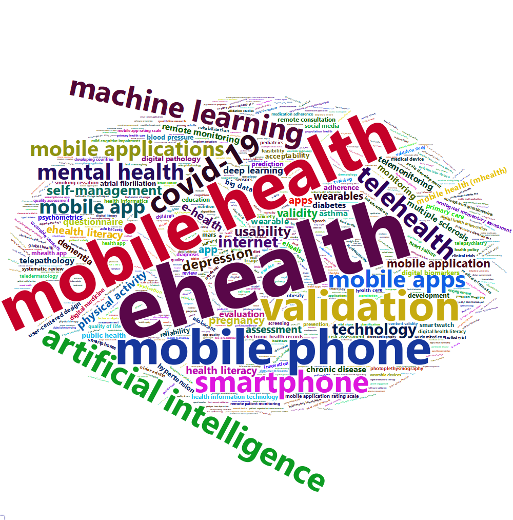

Wordcloud Keywords

## Wordcloud termes Mesh

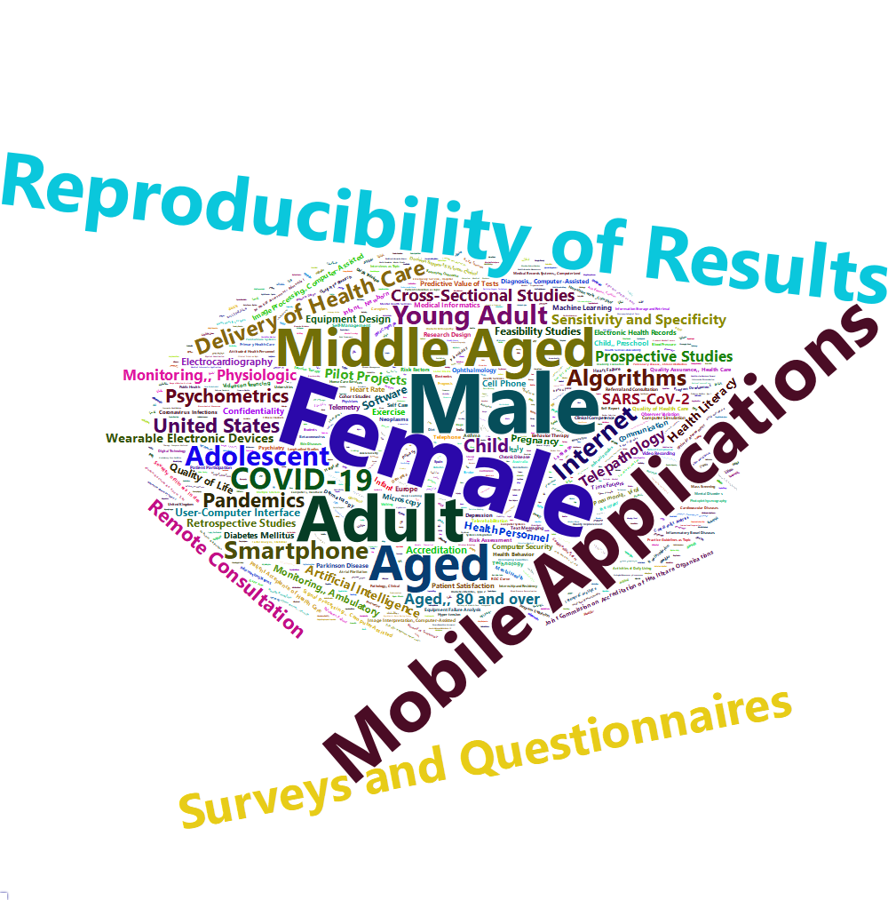

wordcloud Mesh terms

## Termes relatius dissenys / Usabilitat

- Fer taula de frequencies vinculada a la taula disseny

Termes buscats a l’Abstract relatius a disseny

| id | terme | disseny | tipo |
| --- | --- | --- | --- |
| 1 | Cross-sectional | Cross-sectional | Observational |
| 2 | Cross sectional | Cross-sectional | Observational |
| 3 | Cohort | Cohort | Observational |
| 4 | Cohorts | Cohort | Observational |
| 5 | Case-control | Case-control | Observational |
| 6 | Case Control | Case-control | Observational |
| 7 | Observational | Observational | Observational |
| 8 | Experimental | Experimental | Experimental |
| 9 | Clinical trial | RCT | Experimental |
| 10 | Trial | RCT | Experimental |
| 11 | RCT | RCT | Experimental |
| 12 | Systematic review | Systematic review | Systematic review |
| 13 | Meta analysis | Systematic review | Systematic review |
| 14 | Meta-analysis | Systematic review | Systematic review |
| 15 | retrospective study | Retrospective | Observational |
| 17 | predictive study | Predictive study | Observational |
| 18 | machine learning | Predictive study | Observational |
| 19 | survey | Cross-sectional | Observational |
| 20 | Concordance study | Concordance study | Observational |
| 21 | Questionnarie validation | Questionare validation | Observational |
| 22 | Diagnosis test | Concordance study | Observational |
| 23 | test-retest | Questionare validation | Observational |
| 24 | test retest | Questionare validation | Observational |

Termes buscats a l’Abstract relatius a Usabilitat-Satisfacció

| id | terme |
| --- | --- |
| 25 | Usability testing |
| 26 | User experience |
| 27 | User satisfaction assessment |
| 28 | Human-computer interaction |
| 29 | User acceptance testing |
| 30 | User feedback analysis |
| 31 | Satisfaction |
| 32 | User feedback analysis |
| 33 | User interface evaluation |
| 34 | Ease of use assessment |
| 35 | Learnability evaluation |
| 36 | Accessibility testing |
| 37 | User friendliness |
| 38 | User engagement |
| 39 | Acceptability evaluation |
| 40 | Task efficiency assessment |
| 41 | Learnability evaluation |

## Descriptiva I

Summary descriptives table

|  | [ALL] | N |
| --- | --- | --- |
|  | N=1189 |  |
| Design: Yes | 569 (47.9%) | 1189 |
| Design: |  | 412 |
| Cohort | 50 (12.1%) |  |
| Cross-sectional | 158 (38.3%) |  |
| RCT | 170 (41.3%) |  |
| Systematic review | 34 (8.25%) |  |
| Study type: |  | 411 |
| Experimental | 190 (46.2%) |  |
| Observational | 221 (53.8%) |  |
| Concordance study: No | 1189 (100%) | 1189 |
| Usability: Yes | 90 (7.57%) | 1189 |
| Predictive study: Yes | 63 (5.30%) | 1189 |
| Prospective: Yes | 76 (6.39%) | 1189 |
| Retrospective: Yes | 5 (0.42%) | 1189 |
| Questionare validation: Yes | 36 (3.03%) | 1189 |

## Flow-chart

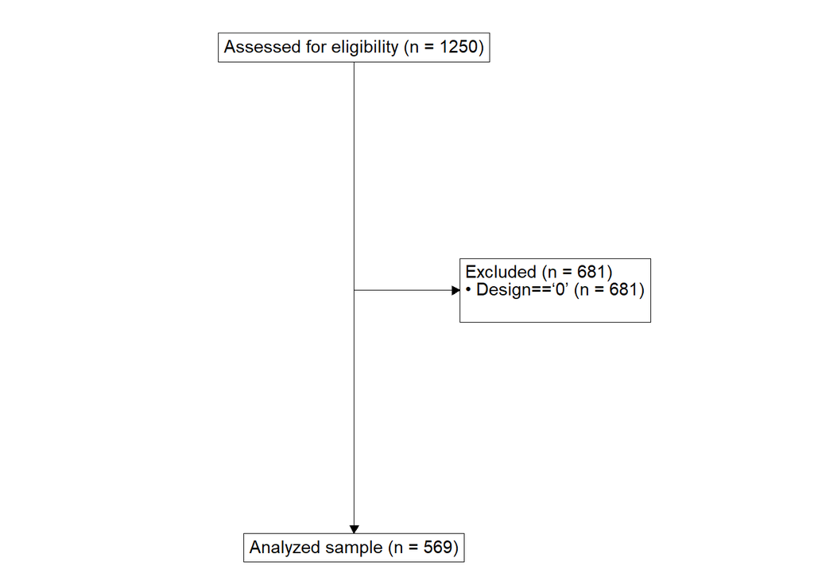

## Descriptiva II

Summary descriptives table

|  | [ALL] | N |
| --- | --- | --- |
|  | N=569 |  |
| Design: Yes | 569 (100%) | 569 |
| Design: |  | 412 |
| Cohort | 50 (12.1%) |  |
| Cross-sectional | 158 (38.3%) |  |
| RCT | 170 (41.3%) |  |
| Systematic review | 34 (8.25%) |  |
| Study type: |  | 411 |
| Experimental | 190 (46.2%) |  |
| Observational | 221 (53.8%) |  |
| Concordance study: No | 569 (100%) | 569 |
| Usability: Yes | 90 (15.8%) | 569 |
| Predictive study: Yes | 63 (11.1%) | 569 |
| Prospective: Yes | 76 (13.4%) | 569 |
| Retrospective: Yes | 5 (0.88%) | 569 |
| Questionare validation: Yes | 36 (6.33%) | 569 |

## Descriptiva de Journal per àmbit

|  | Overall (N=1815) |
| --- | --- |
| Journal |  |
| HEALTH CARE SCIENCES | 392 (21.6%) |
| Others | 357 (19.7%) |
| MEDICAL INFORMATICS | 345 (19.0%) |
| PUBLIC, ENVIRONMENTAL & OCCUPATIONAL HEALTH | 159 (8.8%) |
| PSYCHIATRY | 67 (3.7%) |
| COMPUTER SCIENCE | 66 (3.6%) |
| ENGINEERING | 62 (3.4%) |
| MEDICINE, GENERAL & INTERNA | 39 (2.1%) |
| CARDIAC & CARDIOVASCULAR SYSTEMS | 36 (2.0%) |
| CLINICAL NEUROLOGY | 36 (2.0%) |
| PATHOLOGY - SCIE | 32 (1.8%) |
| HEALTH POLICY & SERVICES | 28 (1.5%) |
| ENVIRONMENTAL SCIENCES | 27 (1.5%) |
| NURSING | 27 (1.5%) |
| CHEMISTRY | 26 (1.4%) |
| INSTRUMENTS | 26 (1.4%) |
| NEUROSCIENCES | 26 (1.4%) |
| MEDICINE, RESEARCH & EXPERIMENTAL | 22 (1.2%) |
| MULTIDISCIPLINARY SCIENCES | 22 (1.2%) |
| PSYCHOLOGY | 20 (1.1%) |

Others: frequency < 1%

### Figura

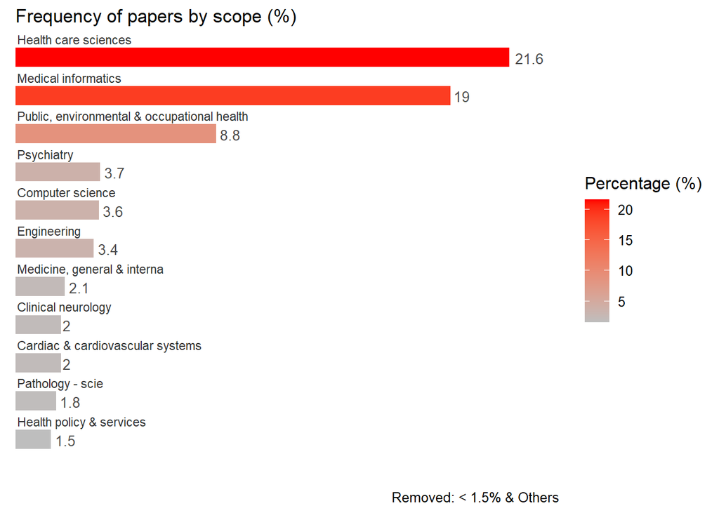

## Evolució de frequencia de papers

- Segons Quartil
- Segons ámbit de revista

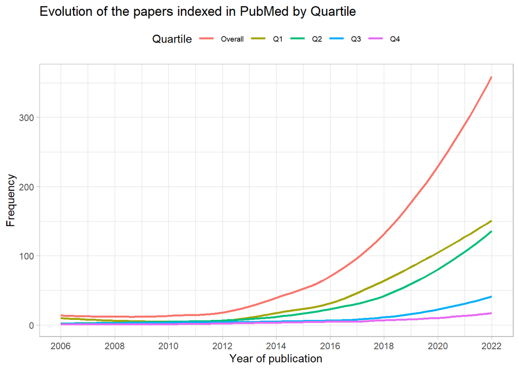

[figure not shown]

## Papers per paisos i regions

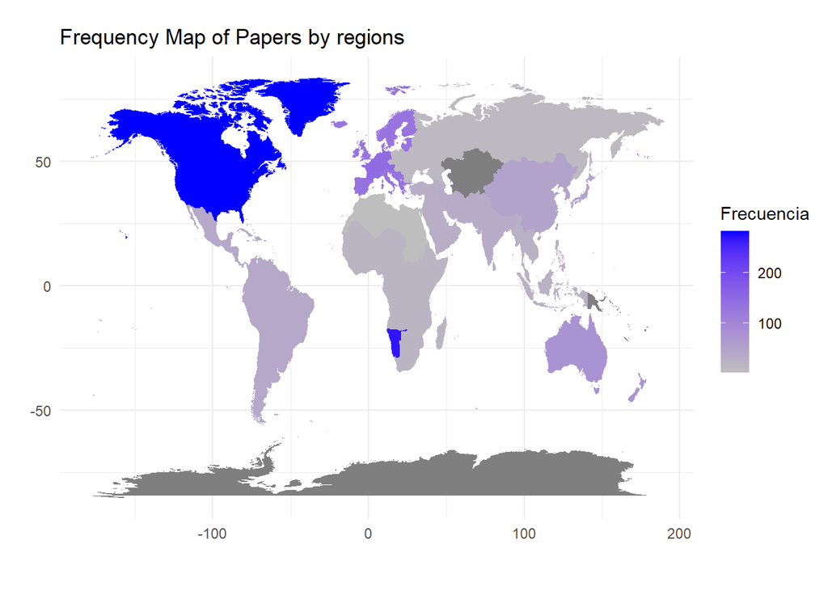

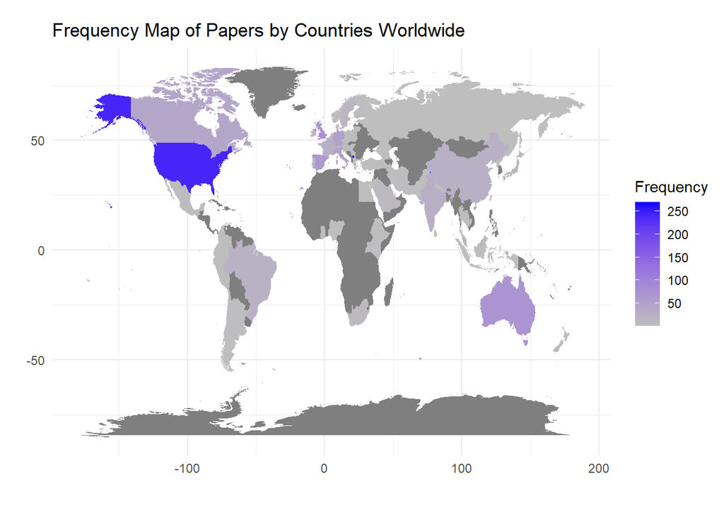

[output not shown]